# Ridge & Lasso

Carry out ridge & Lasso regression.

```r
install.packages("glmnet")
library(glmnet)
```

```r
website <- "https://web.stanford.edu/~hastie/ElemStatLearn/datasets/prostate.data"
prostate <- read.table(website, header=T)
str(prostate)
```

```
'data.frame':   97 obs. of  10 variables:
 $ lcavol : num  -0.58 -0.994 -0.511 -1.204 0.751 ...
 $ lweight: num  2.77 3.32 2.69 3.28 3.43 ...
 $ age    : int  50 58 74 58 62 50 64 58 47 63 ...
 $ lbph   : num  -1.39 -1.39 -1.39 -1.39 -1.39 ...
 $ svi    : int  0 0 0 0 0 0 0 0 0 0 ...
 $ lcp    : num  -1.39 -1.39 -1.39 -1.39 -1.39 ...
 $ gleason: int  6 6 7 6 6 6 6 6 6 6 ...
 $ pgg45  : int  0 0 20 0 0 0 0 0 0 0 ...
 $ lpsa   : num  -0.431 -0.163 -0.163 -0.163 0.372 ...
 $ train  : logi  TRUE TRUE TRUE TRUE TRUE TRUE ...
```

```r
cor(prostate[,1:8])
```

```
           lcavol    lweight       age         lbph         svi          lcp    gleason      pgg45
lcavol  1.0000000 0.28052138 0.2249999  0.027349703  0.53884500  0.675310484 0.43241706 0.43365225
lweight 0.2805214 1.00000000 0.3479691  0.442264399  0.15538490  0.164537142 0.05688209 0.10735379
age     0.2249999 0.34796911 1.0000000  0.350185896  0.11765804  0.127667752 0.26889160 0.27611245
lbph    0.0273497 0.44226440 0.3501859  1.000000000 -0.08584324 -0.006999431 0.07782045 0.07846002
svi     0.5388450 0.15538490 0.1176580 -0.085843238  1.00000000  0.673111185 0.32041222 0.45764762
lcp     0.6753105 0.16453714 0.1276678 -0.006999431  0.67311118  1.000000000 0.51483006 0.63152825
gleason 0.4324171 0.05688209 0.2688916  0.077820447  0.32041222  0.514830063 1.00000000 0.75190451
pgg45   0.4336522 0.10735379 0.2761124  0.078460018  0.45764762  0.631528246 0.75190451 1.00000000
```

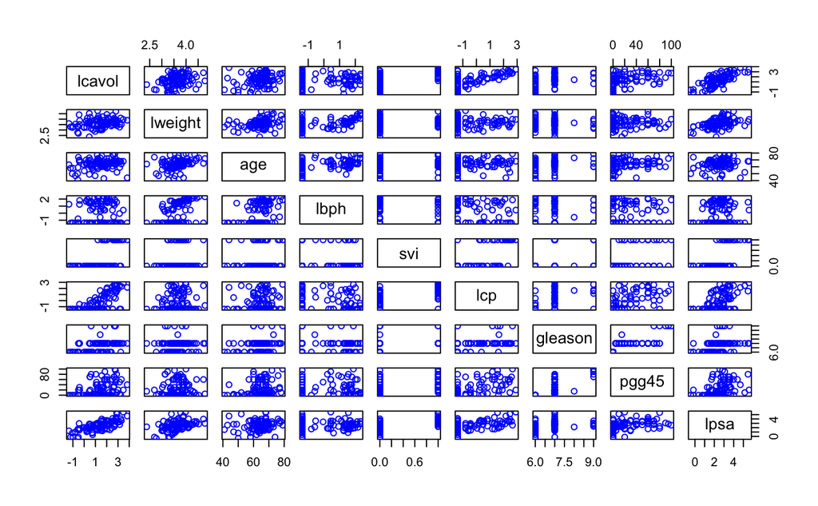

```r
pairs(prostate[,1:9], col="blue")
```

```r
train <- subset(prostate, train == TRUE)[,1:9]
test <- subset(prostate, train == FALSE)[,1:9]
?glmnet
```

Want to fit ridge and lasso regressions to data. In order to do so, need to supply numerical design matrix and responses, so need to convert all factors to numerical predictors. Use data.matrix to do so.

```r
X <- data.matrix(train[,1:8])
Y <- train$lpsa
prostate.ridge <- glmnet(X,Y, family = "gaussian", alpha=0, lambda.min.ratio = 1e-6, nlambda=1000)
```

glmnet solves whole seq of regression problems for different values of lambda. Starts at lambda_max such that regression coefficients are 0 for alpha = 0.001.

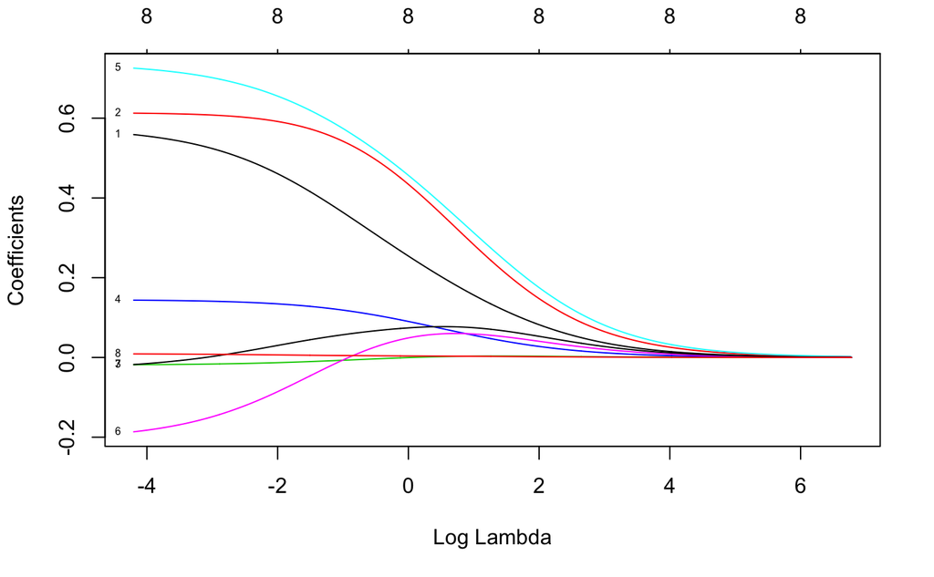

```r
plot(prostate.ridge, xvar="lambda", label=TRUE)
```

Can see that as more deviance is explained by model, model becomes more complicated.

X-Val

```r
set.seed(2018)
prostate.cvridge <- cv.glmnet(X,Y, family = "gaussian",alpha=0, lambda=prostate.ridge$lambda,nfolds=10)
prostate.cvridge$lambda.min
```

```
[1] 0.05416511
```

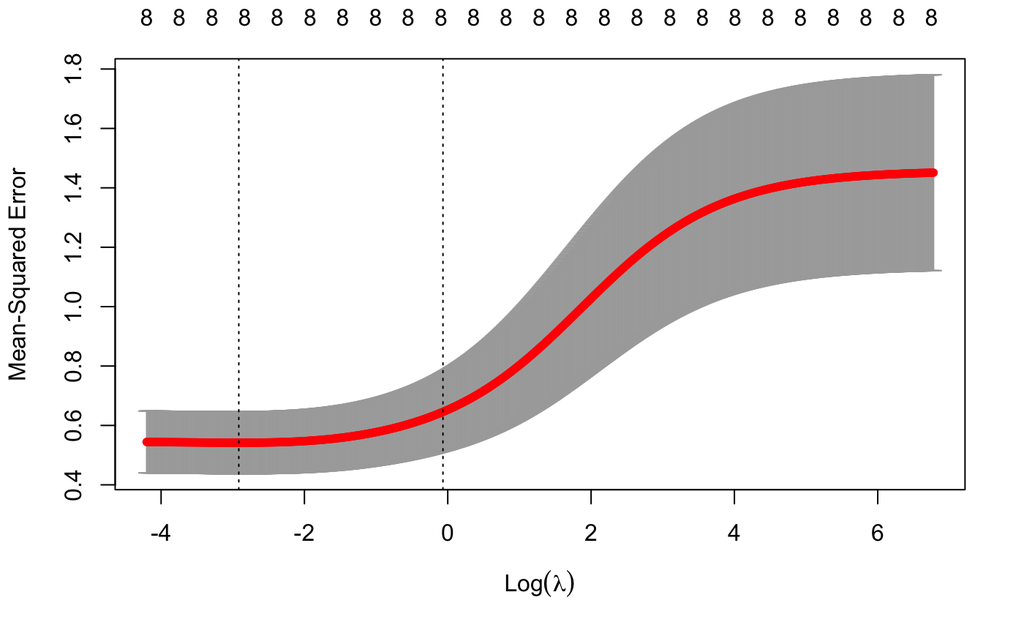

```r
plot(prostate.cvridge)
```

Red curve is avg X-val across K folds. Optimal lambda is first dotted line, second is larges value within 1 sd of optimal.

```r
ind <- prostate.ridge$lambda == prostate.cvridge$lambda.min
round(prostate.ridge$a0[ind], 3) #intercept
```

```
s701
0.19
```

```r
round(prostate.ridge$beta[,ind], 3) #coefficients
```

```
 lcavol lweight     age    lbph     svi     lcp gleason   pgg45
  0.520   0.607  -0.016   0.141   0.699  -0.145   0.004   0.008
```

Now want to check X-val value of lambda against the one that minimises test error

```r
# Find MSE for og model
Yhat <- predict(prostate.ridge, X)
train_err <- colMeans((Y-Yhat)^2)
# Find MSE for new model
X_new <- data.matrix(test[,1:8])
Y_new <- test$lpsa
Y_newhat <- predict(prostate.ridge, X_new)
test_err <- colMeans((Y_new-Y_newhat)^2)
# Compare
plot(log(prostate.ridge$lambda), train_err, col="orange", type="l",ylab="err", xlab="log(lambda)")
points(log(prostate.ridge$lambda), test_err, col="blue", type="l")
```

```r
abline(v=log(prostate.cvridge$lambda.min), lty=3)
abline(v=log(prostate.cvridge$lambda.1se), lty=4)
```

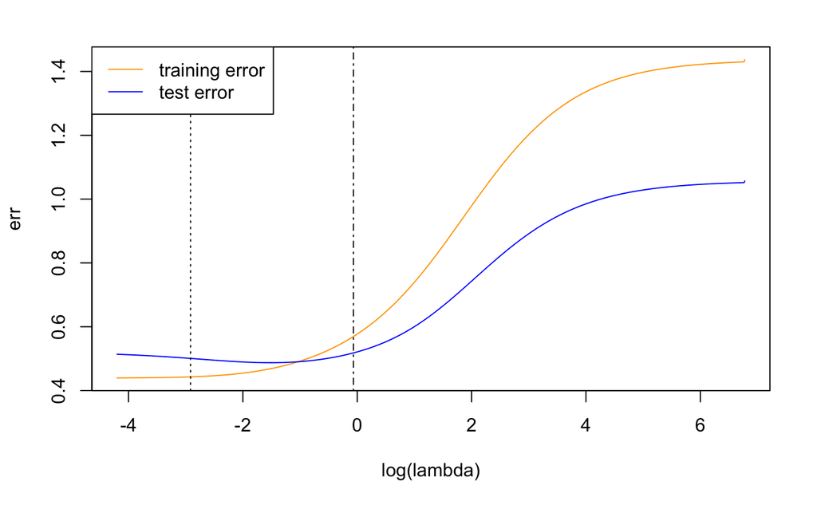

```r
legend("topleft", c("training error","test error"),lty=1, col=c("orange","blue"))
```

Redo with lasso regression.

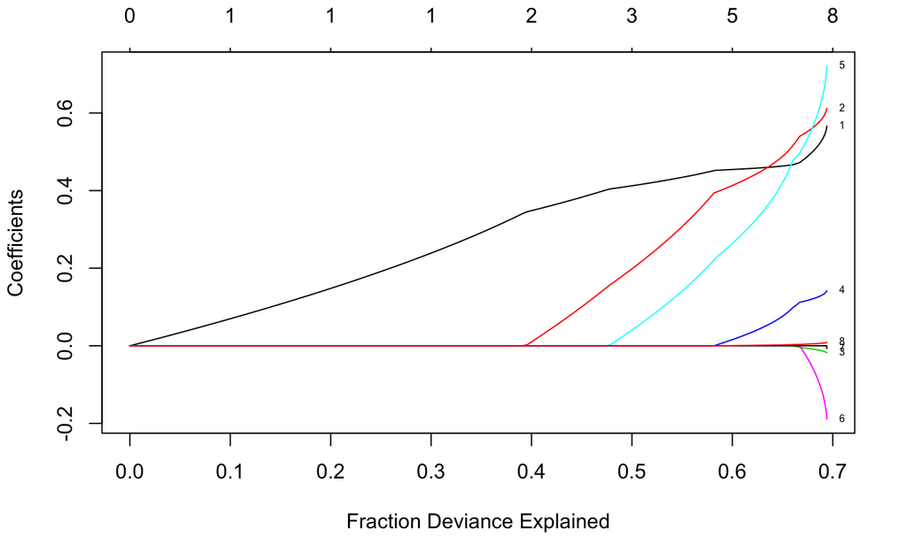

```r
prostate.lasso <- glmnet(X,Y, family = "gaussian", alpha=1, lambda.min.ratio = 1e-6, nlambda=1000)
plot(prostate.lasso, xvar="dev", label=TRUE)
```

Much more sparse as expected. Now find optimal lambda.

```r
prostate.cvlasso <- cv.glmnet(X,Y, family = "gaussian",alpha=0, lambda=prostate.lasso$lambda,nfolds=10)
prostate.cvlasso$lambda.min # optimal regularisation parameter
```

```
[1] 0.05685133
```

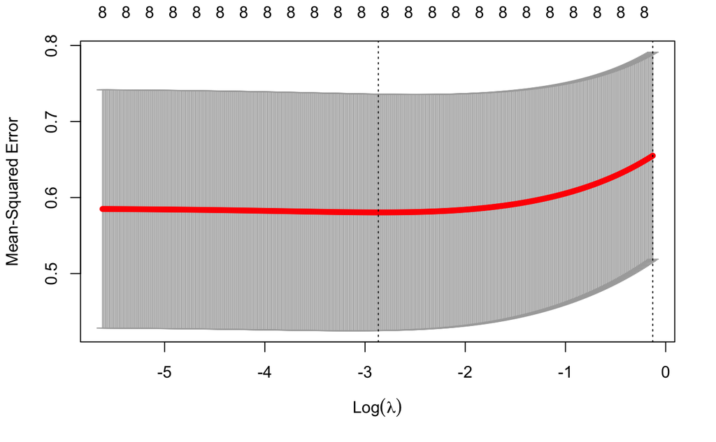

```r
plot(prostate.cvlasso)
```

Find model coeffs

```r
ind_two <- prostate.lasso$lambda == prostate.cvlasso$lambda.min
round(prostate.lasso$a0[ind_two], 3)
```

```
  s198
-0.187
```

```r
round(prostate.lasso$beta[,ind_two], 3)
```

```
 lcavol lweight     age    lbph     svi     lcp gleason   pgg45
  0.468   0.521  -0.001   0.101   0.481   0.000   0.000   0.003
```

GWAS Data

```r
filePath <- "https://raw.githubusercontent.com/AJCoca/SLP19/master/"
fileName <- "gwas.txt"
gwas <- read.table(paste0(filePath, fileName), header=TRUE) # this may take a while
dim(gwas)
```

```
[1]    89 66538
```

```r
gwas[1:10,1:10]
```

|  | pid | disease | rs6681049_1 | rs4074137_1 | rs1891905_1 | rs9729550_1 | rs3813196_1 | rs12044597_1 | rs10907185_1 | rs11260616_1 |
| --- | --- | --- | --- | --- | --- | --- | --- | --- | --- | --- |
| 1 | HCB181 | 1 | 0 | 0 | 1 | 0 | 0 | 1 | 0 | 0 |
| 2 | HCB182 | 1 | 0 | 1 | 1 | 1 | 0 | 0 | 1 | 1 |
| 3 | HCB183 | 0 | 0 | 1 | 1 | 1 | 0 | 1 | 1 | 1 |
| 4 | HCB184 | 1 | 0 | 1 | 1 | 0 | 0 | 1 | 0 | 0 |
| 5 | HCB185 | 1 | 0 | 1 | 0 | 0 | 0 | 1 | 0 | 0 |
| 6 | HCB186 | 1 | 0 | 0 | 1 | 0 | 0 | 0 | 1 | 1 |
| 7 | HCB187 | 1 | 0 | 0 | 1 | 1 | 0 | 1 | 1 | 1 |
| 8 | HCB188 | 1 | 0 | 1 | 1 | 0 | 0 | 1 | 1 | 0 |
| 9 | HCB189 | 0 | 0 | 0 | 0 | 0 | 0 | 1 | 0 | 0 |
| 10 | HCB190 | 0 | 0 | 0 | 0 | 0 | 0 | 1 | 1 | 1 |

```r
install.packages('rje')
library(rje)
```

```r
dev <- rep(0, 66538)
for (j in 1:66536){
  dev[j] <-glm(disease~., family='binomial', data=gwas[,c(2, 2+j)])$deviance
  printPercentage(j, 66538)
}
```

[output not shown]

Do manhattan plot. Red line is bonferroni correction, given by alpha/n.

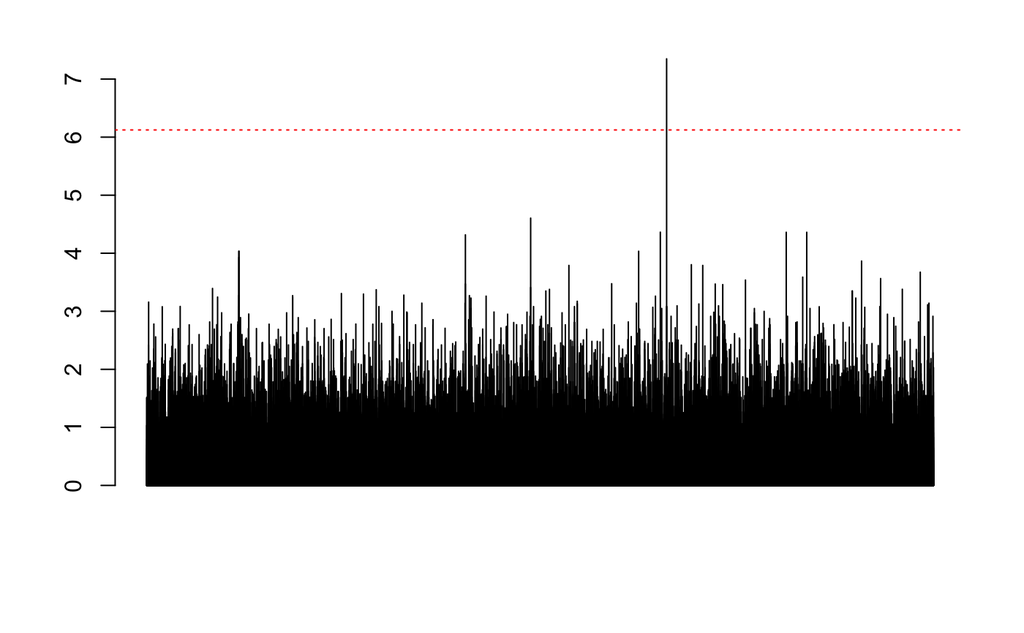

```r
nulldeviance <- glm(disease~1, family='binomial', data=gwas)$deviance
pval <- 1 - pchisq(nulldeviance - dev, 1)
logpval <- rep(0, length(pval))
for (i in 1:length(logpval)){
  if (pval[i] == 0){
    logpval[i] = 0
  } else {
    logpval[i] = -log10(pval[i])
  }
}
barplot(logpval)
abline(h=-log10(0.05/66536), col='red', lty=3)
```

```r
colnames(gwas)[order(pval)[1:6]+2]
```

```
[1] NA             NA             "rs1015896_2"  "rs1119114_1"  "rs10830072_1" "rs7182018_1"
```

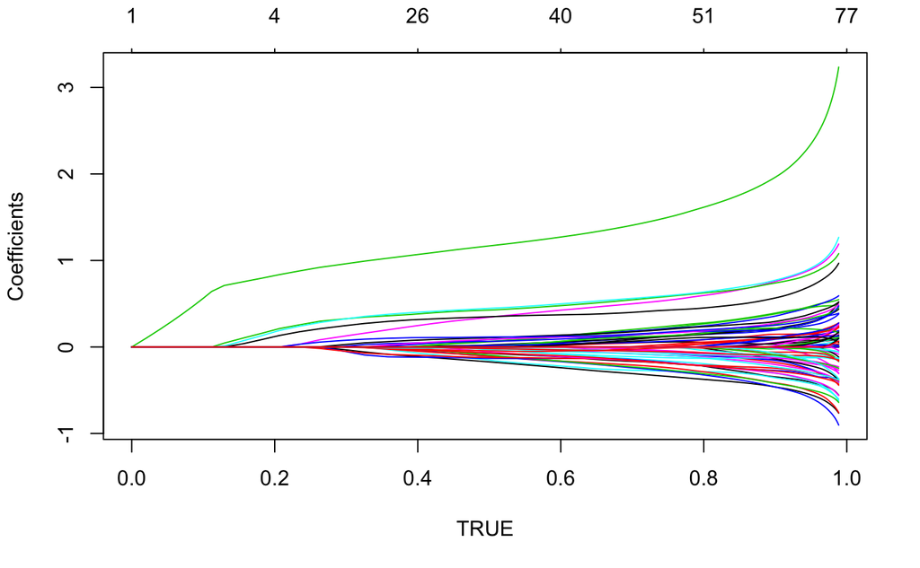

```r
X<-data.matrix(gwas[,-c(1,2)])
Y<-gwas$disease

gwas.lasso <- glmnet(X,Y,family='binomial', alpha=1)
plot(gwas.lasso, xlab=TRUE, xvar="dev")
```

Now tune param using 10-fold X-val

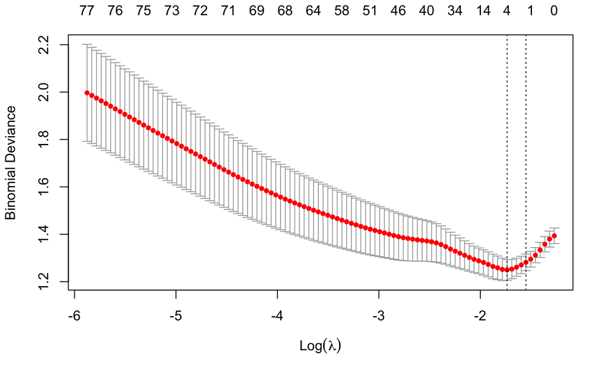

```r
set.seed(2018)
gwas.cvlasso <- cv.glmnet(X,Y, family='binomial', alpha=1, lambda=gwas.lasso$lambda,nfolds=10)
plot(gwas.cvlasso)
```

```r
gwas.cvlasso$lambda.min
```

```
[1] 0.1761613
```

```r
ind <- gwas.lasso$lambda == gwas.cvlasso$lambda.min
round(gwas.lasso$a0[ind], 3)
```

```
   s10
-0.408
```

```r
betahat<-round(gwas.lasso$beta[,ind], 3)
betahat[betahat!=0]
```

```
 rs9482200_2  rs1119114_1 rs10830072_1  rs1015896_2
       0.159        0.133        0.087        0.796
```

```r
?glmnet
```